# roy_deblina

### Test Items starts from here - There are 5 sections - 50 points total

Read each question carefully and address each element. Do not output contents of vectors or data frames unless requested.

##### Section 1: (8 points) This problem deals with vector manipulations.

(1)(a) Create a vector that contains the following, in this order, and output the final, resulting vector. Do not round any values, unless requested. * A sequence of integers from 0 to 4, inclusive. * The number 13 * Three repetitions of the vector c(2, -5.1, -23). * The arithmetic sum of 7/42, 3 and 35/42

```r
vec <- c(0:4, 13, rep(c(2, -5.1, -23), 3), 7/42 + 3 + 35/42)
vec
```

```
##  [1]   0.0   1.0   2.0   3.0   4.0  13.0   2.0  -5.1 -23.0   2.0  -5.1 -23.0
## [13]   2.0  -5.1 -23.0   4.0
```

(1)(b) Sort the vector created in (1)(a) in ascending order. Output this result. Determine the length of the resulting vector and assign to “L”. Output L. Generate a descending sequence starting with L and ending with 1. Add this descending sequence arithmetically the sorted vector. This is vector addition, not vector combination. Output the contents. Do not round any values.

```r
sorted_vec <- sort(vec)
sorted_vec
```

```
##  [1] -23.0 -23.0 -23.0  -5.1  -5.1  -5.1   0.0   1.0   2.0   2.0   2.0   2.0
## [13]   3.0   4.0   4.0  13.0
```

```r
L <- length(sorted_vec)
L
```

```
## [1] 16
```

```r
desc_seq <- seq(L, 1)
desc_seq
```

```
##  [1] 16 15 14 13 12 11 10  9  8  7  6  5  4  3  2  1
```

```r
added_vec <- sorted_vec + desc_seq
added_vec
```

```
##  [1] -7.0 -8.0 -9.0  7.9  6.9  5.9 10.0 10.0 10.0  9.0  8.0  7.0  7.0  7.0  6.0
## [16] 14.0
```

(1)(c) Extract the first and last elements of the vector you have created in (1)(b) to form another vector of the extracted elements. Form a third vector from the elements not extracted. Output these vectors.

```r
first_last <- c(added_vec[1], added_vec[length(added_vec)])
first_last
```

```
## [1] -7 14
```

```r
middle_element <- added_vec[2 :(length(added_vec)-1)]
middle_element
```

```
##  [1] -8.0 -9.0  7.9  6.9  5.9 10.0 10.0 10.0  9.0  8.0  7.0  7.0  7.0  6.0
```

(1)(d) Use the vectors from (c) to reconstruct the vector in (b). Output this vector. Sum the elements.

```r
reconstruct_vec <- c(first_last[1], middle_element, first_last[2])
reconstruct_vec
```

```
##  [1] -7.0 -8.0 -9.0  7.9  6.9  5.9 10.0 10.0 10.0  9.0  8.0  7.0  7.0  7.0  6.0
## [16] 14.0
```

```r
total_sum <- sum(reconstruct_vec)
total_sum
```

```
## [1] 84.7
```

```r
Trigfunction <- function(x) {
  y <- sin(x) + cos(x/2)
  return(y)
}
```

(2)(b) Create a vector, x, of 4001 equally-spaced values from -2 to 2, inclusive. Compute values for y using the vector x and your function from (2)(a). **Do not output x or y.** Find the value in the vector x that corresponds to the maximum value in the vector y. Restrict attention to only the values of x and y you have computed; i.e. do not interpolate. Round to 3 decimal places and output both the maximum y and corresponding x value.

Finding the two desired values can be accomplished in as few as two lines of code. Do not use packages or programs you may find on the internet or elsewhere. Do not output the other elements of the vectors x and y. Relevant coding methods are given in the *Quick Start Guide for R*.

```r
x <- seq(-2, 2, length.out = 4001)
y <- Trigfunction(x)
max_y <- round(max(y), 3)
x_at_max_y <- round(x[which.max(y)], 3)
max_y
```

```
## [1] 1.76
```

```r
x_at_max_y
```

```
## [1] 1.27
```

(2)(c) Plot y versus x in color, with x on the horizontal axis. Show the location of the maximum value of y determined in 2(b). Show the values of x and y corresponding to the maximum value of y in the display. Add a title and other features such as text annotations. Text annotations may be added via *text()* for base R plots and *geom_text()* or *geom_label()* for ggplots.

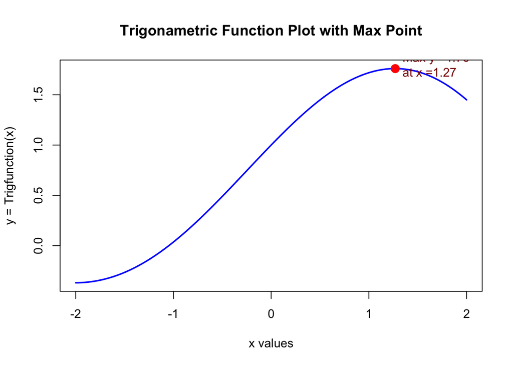

```r
 # Plot y versus x in color
plot(x, y, type = "l", col = "blue", lwd = 2,
  main = "Trigonametric Function Plot with Max Point",
  xlab = "x values", ylab = "y = Trigfunction(x)")
points(x_at_max_y, max_y, col = "red", pch = 19, cex = 1.5)
text(x_at_max_y, max_y,
     labels = paste0("Max y =", max_y, "\nat x =", x_at_max_y),
     pos = 4, offset = 0.5, col = "darkred")
```

##### Section 3: (8 points) This problem requires finding the point of intersection of two functions. Using the function `y = cos(x / 2) * sin(x / 2)`, find where the curved line y = -(x/2)^3 intersects it within the range of values used in part (2) (i.e. 4001 equally-spaced values from -2 to 2). Plot both functions on the same display, and show the point of intersection. Present the coordinates of this point as text in the display.

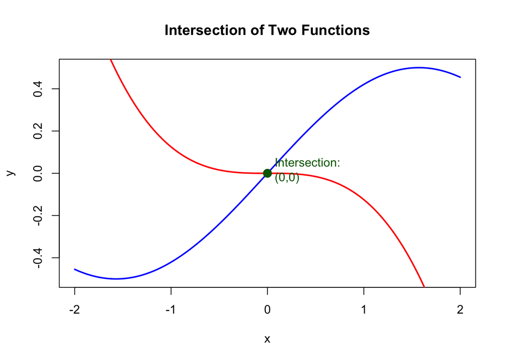

```r
#generate the vector x
x <- seq(-2, 2, length.out = 4001)
#define the two function
y1 <- cos(x / 2) * sin(x / 2)
y2 <- -(x/2)^3
#find the point of intersection
diff <- abs(y1 - y2)
i <- which.min(diff)
#extract the intersection coordinates
x_int <- x[i]
y_int <- y1[i]
#plot the two function
plot(x, y1, type = "l", col = "blue", lwd = 2,
     main = "Intersection of Two Functions",
     xlab = "x", ylab = "y")
lines(x, y2, col = "red", lwd = 2)
#Highlight the point of intersection
points(x_int, y_int, col = "darkgreen", pch = 19, cex = 1.5)
#Annotate the point
text(x_int, y_int,
     labels = paste0("Intersection:\n(",
                      round(x_int, 3), ",",
                      round(y_int, 3), ")"),
     pos = 4, offset = 0.5, col = "darkgreen")
```

##### Section 4: (12 points) Use the “trees” dataset for the following items. This dataset has three variables (Girth, Height, Volume) on 31 felled black cherry trees.

(4)(a) Use *data(trees)* to load the dataset. Check and output the structure with *str()*. Use *apply()* to return the median values for the three variables. Output these values. Using R and logicals, output the row number and the three measurements - Girth, Height and Volume - of any trees with Girth equal to median Girth. It is possible to accomplish this last request with one line of code.

```r
data(trees)
str(trees)
```

```
## 'data.frame':    31 obs. of  3 variables:
##  $ Girth : num  8.3 8.6 8.8 10.5 10.7 10.8 11 11 11.1 11.2 ...
##  $ Height: num  70 65 63 72 81 83 66 75 80 75 ...
##  $ Volume: num  10.3 10.3 10.2 16.4 18.8 19.7 15.6 18.2 22.6 19.9 ...
```

```r
apply(trees, 2, median)
```

```
##  Girth Height Volume
##   12.9   76.0   24.2
```

```r
trees[trees$Girth == median(trees$Girth), ]
```

```
##    Girth Height Volume
## 16  12.9     74   22.2
## 17  12.9     85   33.8
```

```r
data(trees)
radius <- trees$Girth / (2 * pi)
area <- pi * radius^2
stem(radius)
```

```
##
##   The decimal point is 1 digit(s) to the left of the |
##
##   12 | 27
##   14 | 0
##   16 | 7025578
##   18 | 01161
##   20 | 5528
##   22 | 0361
##   24 | 59
##   26 | 59
##   28 | 566
##   30 |
##   32 | 8
```

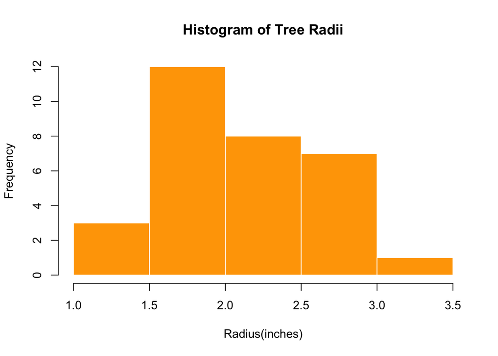

```r
hist(radius,
     main = "Histogram of Tree Radii",
     xlab = "Radius(inches)",
     col = "orange",
     border = "white")
```

(4)(c) Present a horizontal, notched, colored boxplot of the areas calculated in (b). Title and label the axis.

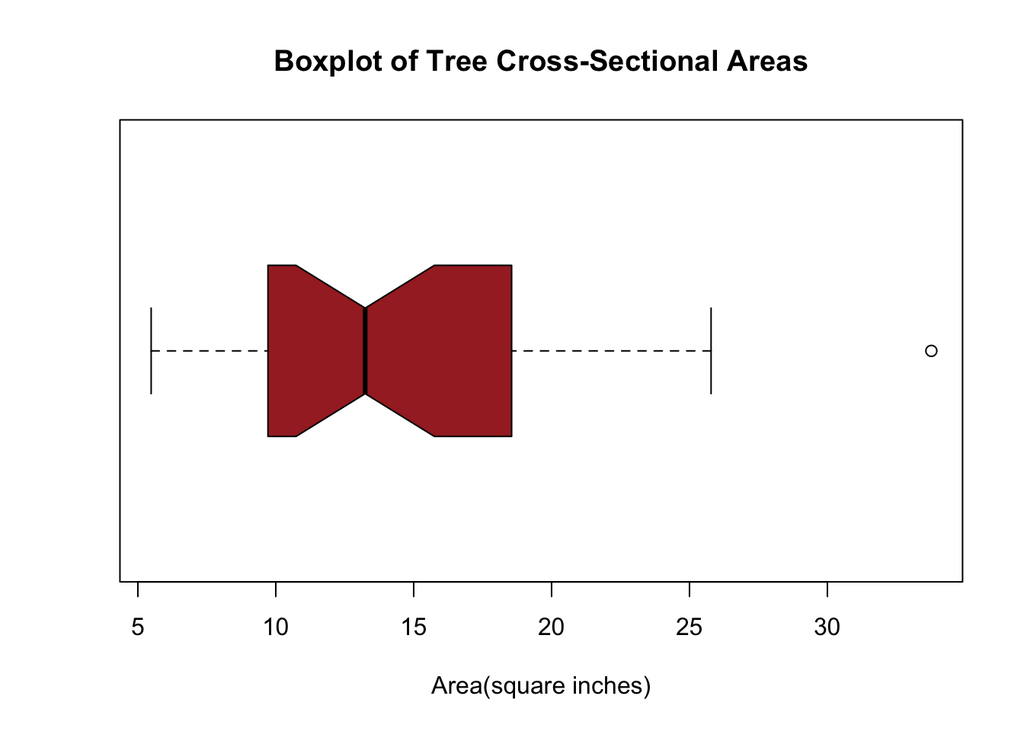

```r
boxplot(area,
        notch = TRUE,                                     #adds notch to indicate median confidence value
        horizontal = TRUE,                                #makes the boxplot horizontal
        col = "brown",                                    #sets the color of the box
        main = "Boxplot of Tree Cross-Sectional Areas",   #title of the plot
        xlab = "Area(square inches)")                     #label for the x-axis
```

(4)(d) Demonstrate that the outlier revealed in the boxplot of Area is not an extreme outlier. (Note: Extreme outlier is defined as a value that falls outside the boundaries of Q1- 3*IQR and Q3+ 3*IQR. Note that R uses Q1 -1.5*IQR and Q3+1.5*IQR as default values to identify outliers). It is possible to do this with one line of code using *boxplot.stats()* or ‘manual’ calculation and logicals. Identify the tree with the largest area and output on one line its row number and three measurements.

```r
boxplot.stats(area, coef = 3)$out
```

```
## numeric(0)
```

```r
trees[which.max(area),]
```

```
##    Girth Height Volume
## 31  20.6     87     77
```

```r
cat("Tree with largest area:\nRow:", which.max(area), "->", unlist(trees[which.max(area), ]), "\n")
```

```
## Tree with largest area:
## Row: 31 -> 20.6 87 77
```

##### Section 5: (12 points) The exponential distribution is an example of a right-skewed distribution with outliers. This problem involves comparing it with a normal distribution which typically has very few outliers.

5(a) Use *set.seed(124)* and *rexp()* with n = 100, rate = 5.5 to generate a random sample designated as y. Generate a second random sample designated as x with *set.seed(127)* and *rnorm()* using n = 100, mean = 0 and sd = 0.15.

Generate a new object using *cbind(x, y)*. Do not output this object; instead, assign it to a new name. Pass this object to *apply()* and compute the inter-quartile range (IQR) for each column: x and y. Use the function *IQR()* for this purpose. Round the results to four decimal places and present (this exercise shows the similarity of the IQR values.).

For information about *rexp()*, use *help(rexp)* or *?rexp()*. **Do not output x or y.**

```r
set.seed(124)
y <- rexp(n = 100, rate = 5.5)

set.seed(127)
x <- rnorm(n = 100, mean = 0, sd = 0.15)

data_matrix <- cbind(x, y)
round(apply(data_matrix, 2, IQR), 4)
```

```
##      x      y
## 0.2041 0.2164
```

(5)(b) This item will illustrate the difference between a right-skewed distribution and a symmetric one. For base R plots, use *par(mfrow = c(2, 2))* to generate a display with four diagrams; *grid.arrange()* for ggplots. On the first row, for the normal results, present a histogram and a horizontal boxplot for x in color. For the exponential results, present a histogram and a horizontal boxplot for y in color.

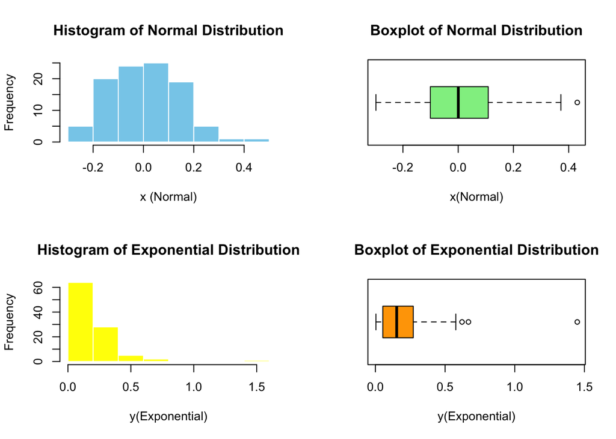

```r
#Set up plotting area
par(mfrow = c(2, 2))

#Histogram for normal distribution(x)
hist(x, main = "Histogram of Normal Distribution",
     col = "skyblue", xlab = "x (Normal)", border = "white")

#Horizontal boxplot of normal distribution(x)
boxplot(x, horizontal = TRUE, col = "lightgreen",
        main = "Boxplot of Normal Distribution", xlab = "x(Normal)")

#Histogram of exponential distribution (y)
hist(y, main = "Histogram of Exponential Distribution",
     col = "yellow", xlab = "y(Exponential)", border = "white")

#Horizontal boxplot of exponential distribution (y)
boxplot(y, horizontal = TRUE, col = "orange",
        main = "Boxplot of Exponential Distribution", xlab = "y(Exponential)")
```

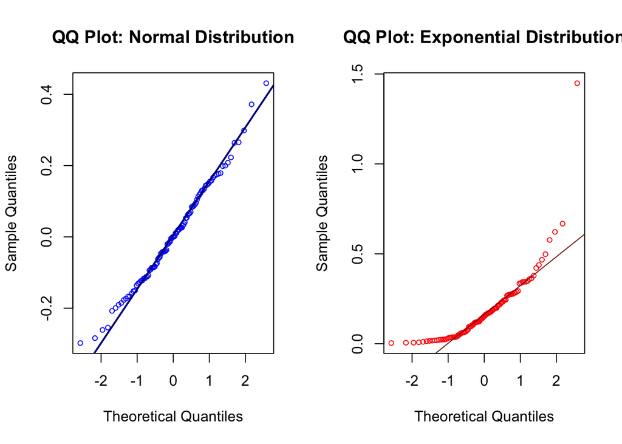

```r
#Setup plotting window for side by side plots
par(mfrow = c(1, 2))

#QQ Plot for Normal Distribution (x)
qqnorm(x, main = "QQ Plot: Normal Distribution", col = "blue", cex = 0.7)
qqline(x, col = "darkblue", lwd = 2)

#QQ Plot for Exponential Distribution (y)
qqnorm(y, main = "QQ Plot: Exponential Distribution", col = "red", cex = 0.7)
qqline(y, col = "darkred", lwd =)
```